# Decomposition model for forecasting workthrough

This is a demonstration of using additive/multiplactive decomposition model for a monthly time series data for forecast. The model module is provided on [link](https://github.com/onefless/Time-series-prediction-of-monthly-data). Please note that the module restricts to ONLY monthly data, and the index must be 'Datetime Index'.

The data used for this demonstration is total arrivals of passengers to Australia, which is provided by [Australian Bureau of Statistics](https://www.abs.gov.au/AUSSTATS/abs@.nsf/DetailsPage/3401.0Jan%202019?OpenDocument) and is cleaned after download. Forecasting such data would help local governments to draw plan for public transport, municipal projects, and urban security.

```python
import numpy as np
import pandas as pd
import matplotlib.pyplot as plt
%matplotlib inline
```

```python
# import and visualise data
parser = lambda dates: pd.datetime.strptime(dates,'%b-%Y')
data = pd.read_csv('C:\\Users\Francis\Desktop\乾\Python playground\Australian tourists\Australian_tourists_total_arrivals.csv',engine='python',parse_dates=[0], index_col = 'Time' ,date_parser = parser)

print(data.head())
print(data.tail()) # The data starts from Jan 1976 to Dec 2018.
```

```
            Total arrivals
Time
1976-01-01          203000
1976-02-01          137000
1976-03-01          119000
1976-04-01          102100
1976-05-01          129000
            Total arrivals
Time
2018-08-01         1718600
2018-09-01         1722000
2018-10-01         1963700
2018-11-01         1668000
2018-12-01         1853600
```

```python
def show_plot(data,figsize= (15,10), color = 'blue', linestyle = '-', xlabel = 'Time', ylabel='Total arrivals', label = None):
    plt.figure(figsize= figsize)
    plt.plot(data.index,data,color = color,label = label)
    plt.xlabel(xlabel)
    plt.ylabel(ylabel)
    plt.legend(loc = 2)
```

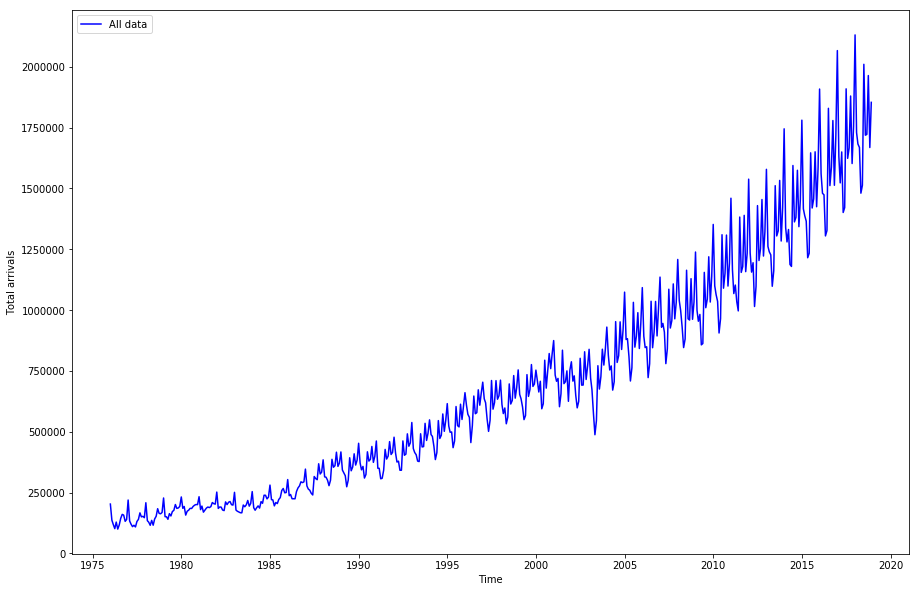

```python
show_plot(data,label = 'All data')
```

Therefore, the data is suitable for decomposition model. The iregular patterns (outliers) can be either replaced by predicted values, or be avoided in training. In this example, I only train and test the values after 2005.

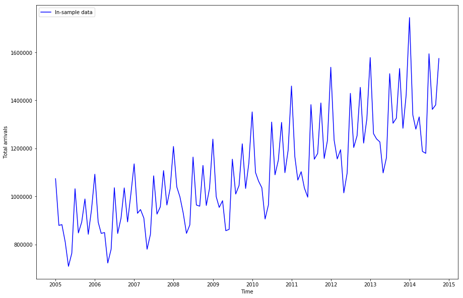

```python
# cut down samples and train-test split.
def year_cut(data,time):
    '''
    data: df, (n,1), index type must be DatetimeIndex, must be 1
    time: str,'MMM-YYYY'. Must comply with date form in data.
    '''
    return data[time:]

def tt_split(data,seperator=0.7):
    '''
    Input:
        data: df, (n,1)
        seperator: float, (0,1). string, 'MMM-YYYY'.
    Output:
        trainin, test: df
    '''
    try:
        n = int(data.shape[0]*seperator)
        return data[:n+1],data[n+1:]
    except:
        return data[:seperator],data[seperator:]

data_ten_y = year_cut(data,'Jan-2005') # Cut the original data from Jan 2005.
train,test = tt_split(data_ten_y) # First 70% data is used as in-sample data, the rest is out-of-sample.
show_plot(train,label = 'In-sample data')
```

## Firstly use additive decomposition model

Bear in mind that the initial plot suggests mupltiplicative model.

```python
# Copy and past module
class decomposition_additive(object):
    '''
    Apply additive decomposition model to evenly spaced monthly time series problem. It allows forecast and vishualisation.
    '''

    def __init__(self,order = 2, cycle = None):
        '''
        Arguments:
            order: int, order for polymonial regression
            Cycle: TBA
            metrics: str, 'rmse' TBA
        '''
        self.cycle = cycle
        self.order = order

    def seasonal_component(self):
        '''
        Output:
            seasonal_full: Series, (12,). Seasonal component.
        Note: self.seasonal returns only 12 monthly data. self.seasonal_full is the complete seasonal component.
        '''
        try:
            np
        except:
            import numpy as np
        try:
            pd
        except:
            import pandas as pd

        coef = np.polyfit(np.arange(len(self.original)),self.original_1d,self.order)
        poly_mdl = np.poly1d(coef)
        trend = pd.Series(data = poly_mdl(np.arange(len(self.original))),index = self.index)

        self.detrended = self.original.iloc[:,0] - trend
        self.seasonal = self.detrended.groupby(by = self.detrended.index.month).mean()

        self.seasonal_full = self.original.copy()
        for i in self.seasonal.index:
            self.seasonal_full.loc[self.seasonal_full.index.month == i,self.col_name] =self.seasonal.loc[i]

        return self.seasonal_full

    def trend_component(self):
        '''
        Output:
            trend: Series, (n,). Trend component.
        '''
        self.seasonal_component()
        for i in self.seasonal.index:
            self.deseasonal = self.original.subtract(self.seasonal.loc[i],
                                                     level = (self.original.index.month == i))

        coef = np.polyfit(np.arange(len(self.deseasonal)),self.original_1d,self.order)
        self.poly_mdl = np.poly1d(coef) #polynominal model
        self.trend = pd.Series(data = self.poly_mdl(np.arange(len(self.deseasonal))),index = self.index)

        return self.trend

    def fit(self,original):
        '''
        original: df, (n*1). ONLY MONTHLY DATA. Must not have missing months. Index must be Timestamp
        '''

        self.original = original
        self.original_1d = original.values.ravel()
        self.index = original.index
        self.col_name = original.columns[0]
        self.trend_component()
        self.residual = pd.Series(data = (self.original.values.ravel() - self.seasonal_full.values.ravel() - self.trend.values.ravel()),index = self.index)
        rmse_training = np.sqrt((((self.trend.values.ravel()+self.seasonal_full.values.ravel()) - self.original_1d) ** 2).mean())
        print('The training RMSE is:{}'.format(rmse_training))

    def test(self,test_data, metrics = 'rmse'):
        '''
        Argument:
            test_Data: df, (n*1). Test date must be continueous with training.
        Output:
            prediction_test: Series, (n,)
        '''

        self.test_data = test_data
        self.test_index = test_data.index
        self.metrics = metrics.lower()

        #seasonal test
        if self.test_data.columns[0] != self.col_name:
            self.test_data.rename(index=str,columns={self.test_data.columns[0]:self.col_name})
        self.seasonal_full_test = self.test_data.copy()
        for i in self.seasonal.index:
            self.seasonal_full_test.loc[self.seasonal_full_test.index.month == i, self.col_name] = self.seasonal.loc[i]
        #deseasonal test
        self.deseasonal_test = pd.Series(data = (self.test_data.values - self.seasonal_full_test.values).ravel(),index = self.test_index)

        #trend test
        poly_values = self.poly_mdl(np.arange(len(self.test_data)+len(self.original)))
        self.trend_test = pd.Series(data = poly_values[-self.test_data.shape[0]:],index = self.test_index)
        self.prediction_test = self.trend_test+self.seasonal_full_test.iloc[:,0]
        self.residual_test = pd.Series(data = (self.test_data.values.ravel() - self.seasonal_full_test.values.ravel() - self.trend_test.values.ravel()),index = self.test_index)
        rmse_test = np.sqrt(((self.prediction_test.values.ravel() - self.test_data.values.ravel()) ** 2).mean())
        print('The test RMSE is:{}'.format(rmse_test))
        return self.prediction_test

    def predict(self,months = 36):
        '''
        Arguments:
            month: int, how many months to be predicted after original.
        Output:
            prediction: Series, (n,)
        '''
        from dateutil.relativedelta import relativedelta
        new_index = pd.date_range(self.index[-1]+relativedelta(months = 1),self.index[-1]+relativedelta(months = months),freq='MS')
        self.seasonal_full_pred = pd.Series(data = np.zeros(months),index = new_index)
        for i in self.seasonal.index:
            self.seasonal_full_pred.loc[self.seasonal_full_pred.index.month == i] = self.seasonal.loc[i]
        poly_values = self.poly_mdl(np.arange(len(new_index)+len(self.original)))
        self.trend_pred = pd.Series(data = poly_values[-months:],index = new_index)
        self.prediction = self.trend_pred + self.seasonal_full_pred
        return self.prediction

    def plot_components(self,data = 'training'):
        '''
        ***Credit: modified from the code by Marcel Scharth (Github: https://github.com/mscharth).
        Plot Plot original data, seasonal component, trend component and residual, also predicted values for 'test'.
        Arguments:
            data: 'training' or 'test', str. Which data to be plotted.
        '''
        try:
            plt
        except:
            import matplotlib.pyplot as plt
        if data == 'training':
            fig, ax = plt.subplots(4, sharex=True,figsize = (15,10))
            self.original.plot(ax=ax[0],color='b', linestyle='-')
            ax[0].set_title('Original')

            self.trend.plot(ax=ax[1], color='r', linestyle='-')
            ax[1].set_title('Trend line (Order = {}.)'.format(self.order))

            self.seasonal_full.plot(ax=ax[2], color='g', linestyle='-')
            ax[2].set_title('Seasonal component')

            self.residual.plot(ax=ax[3], color='k', linestyle='-')
            ax[3].set_title('Residual plot')
        if data == 'test':
            fig, ax = plt.subplots(4, sharex=True)
            self.test_data.plot(ax=ax[0],color='b', linestyle='-')
            self.prediction_test.plot(ax=ax[0],color='r', linestyle='-')
            ax[0].set_title('Test data')

            self.trend_test.plot(ax=ax[1], color='r', linestyle='-')
            ax[1].set_title('Trend line (Order = {}.)'.format(self.order))

            self.seasonal_full_test.plot(ax=ax[2], color='g', linestyle='-')
            ax[2].set_title('Seasonal component')

            self.residual_test.plot(ax=ax[3], color='k', linestyle='-')
            ax[3].set_title('Residual plot')

    def plot_test(self,data = 'test'):
        '''
        arugments:
            data: 'test' or 'training'
        '''
        try:
            plt
        except:
            import matplotlib.pyplot as plt
        if data == 'test':
            self.test_data.plot(color='b',linestyle='-', figsize = (15,10),label = 'Out-of-sample')
            self.prediction_test.plot(color='r',linestyle='-',label = 'Predicted out-of-sample')
            plt.legend(loc = 2)
        if data == 'training':
            self.original.plot(color='b',linestyle='-',  figsize = (15,10))
            training_pred = pd.Series(data = (self.trend.values.ravel() + self.seasonal_full.values.ravel()),index = self.index)
            training_pred.plot(color='r',linestyle='-',label = 'Predicted in-sample')
            plt.legned(loc = 2)
```

```python
# Training and testing
decomp = decomposition_additive()

decomp.fit(train) # Train the model with in-sample data, training RMSE will be printed.

test_pred = decomp.test(test) # Test the model with out-of-sample data, test RMSE will be printed.
```

```
The training RMSE is:31014.91899913728
The test RMSE is:64840.87558139789
```

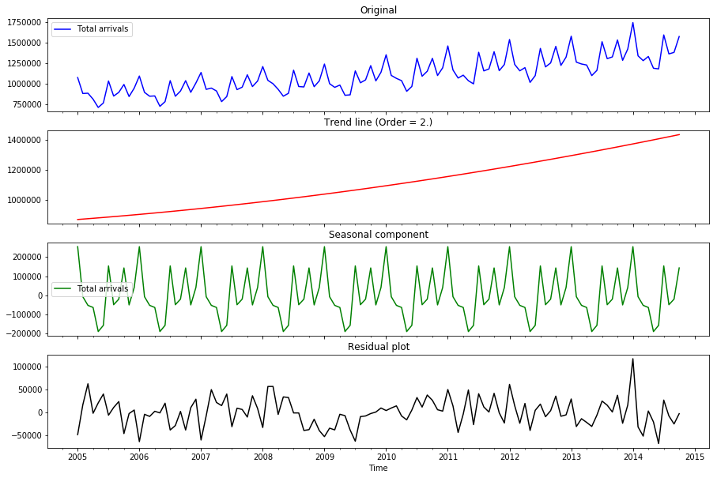

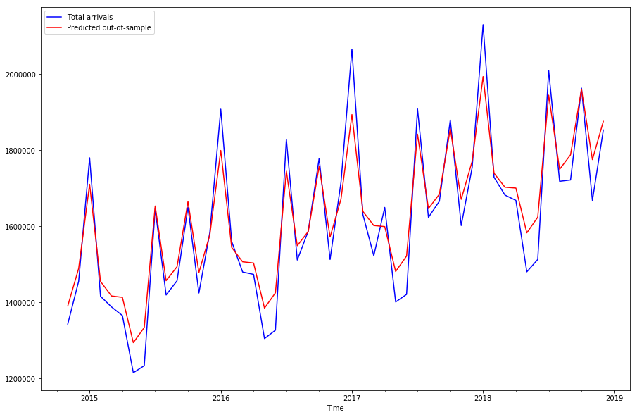

```python
# Visualisation
decomp.plot_components(data = 'training')
decomp.plot_test(data = 'test')
```

```python
# Extract components (optional)
seasonal_component = decomp.seasonal_full
trend_componenent = decomp.trend
residual = decomp.residual

# Prediction for 36 months after the end of training
prediction = decomp.predict(months = 36)
```

## Now try multiplicative decomposition model

```python
# Copy and past the module
class decomposition_multiplicative(object):

    def __init__(self,order = 2, cycle = None):
        '''
        Arguments:
            order: int, order for polymonial regression
            Cycle: TBA
            metrics: str, 'rmse' TBA
        '''
        self.cycle = cycle
        self.order = order

    def seasonal_component(self):
        '''
        Output:
            seasonal_full: Series, (12,). Seasonal component.
        Note: self.seasonal returns only 12 monthly data. self.seasonal_full is the complete seasonal component.
        '''
        try:
            np
        except:
            import numpy as np
        try:
            pd
        except:
            import pandas as pd

        coef = np.polyfit(np.arange(len(self.original)),self.original_1d,self.order)
        poly_mdl = np.poly1d(coef)
        trend = pd.Series(data = poly_mdl(np.arange(len(self.original))),index = self.index)

        detrended = self.original.iloc[:,0]/trend
        self.seasonal = detrended.groupby(by = detrended.index.month).mean()

        self.seasonal_full = self.original.copy()
        for i in self.seasonal.index:
            self.seasonal_full.loc[self.seasonal_full.index.month == i,self.col_name] =self.seasonal.loc[i]

        return self.seasonal_full

    def trend_component(self):
        '''
        Output:
            trend: Series, (n,). Trend component.
        '''
        self.seasonal_component()
        for i in self.seasonal.index:
            self.deseasonal = self.original.div(self.seasonal.loc[i],
                                                     level = (self.original.index.month == i))

        coef = np.polyfit(np.arange(len(self.deseasonal)),self.original_1d,self.order)
        self.poly_mdl = np.poly1d(coef) #polynominal model
        self.trend = pd.Series(data = self.poly_mdl(np.arange(len(self.deseasonal))),index = self.index)

        return self.trend

    def fit(self,original):
        '''
        original: df, (n*1). ONLY MONTHLY DATA. Must not have missing months. Index must be Timestamp
        '''
        self.original = original
        self.original_1d = original.values.ravel()
        self.index = original.index
        self.col_name = original.columns[0]
        self.trend_component()
        self.residual = pd.Series(data = (self.original.values.ravel() / self.seasonal_full.values.ravel() / self.trend.values.ravel()),index = self.index)
        rmse_training = np.sqrt((((self.trend.values.ravel()*self.seasonal_full.values.ravel()) - self.original_1d) ** 2).mean())
        print('The training RMSE is:{}'.format(rmse_training))

    def test(self,test_data, metrics = 'rmse'):
        '''
        Argument:
            test_Data: df, (n*1). Test date must be continueous with training.
        Output:
            prediction_test: Series, (n,)
        '''

        self.test_data = test_data
        self.test_index = test_data.index
        self.metrics = metrics.lower()

        #seasonal test
        if self.test_data.columns[0] != self.col_name:
            self.test_data.rename(index=str,columns={self.test_data.columns[0]:self.col_name})
        self.seasonal_full_test = self.test_data.copy()
        for i in self.seasonal.index:
            self.seasonal_full_test.loc[self.seasonal_full_test.index.month == i, self.col_name] = self.seasonal.loc[i]
        #deseasonal test
        self.deseasonal_test = pd.Series(data = (self.test_data.values.ravel() / self.seasonal_full_test.values.ravel()),index = self.test_index)

        #trend test
        poly_values = self.poly_mdl(np.arange(len(self.test_data)+len(self.original)))
        self.trend_test = pd.Series(data = poly_values[-self.test_data.shape[0]:],index = self.test_index)
        self.prediction_test = self.trend_test.values.ravel() * self.seasonal_full_test.values.ravel()
        self.prediction_test = pd.Series(data = self.prediction_test, index = self.test_index)
        self.residual_test = pd.Series(data = (self.test_data.values.ravel() / self.seasonal_full_test.values.ravel() - self.trend_test.values.ravel()),index = self.test_index)
        rmse_test = np.sqrt(((self.prediction_test.values.ravel() - self.test_data.values.ravel()) ** 2).mean())
        print('The test RMSE is:{}'.format(rmse_test))
        return self.prediction_test

    def predict(self,months = 36):
        '''
        Arguments:
            month: int, how many months to be predicted after original.
        Output:
            prediction: Series, (n,)
        '''
        from dateutil.relativedelta import relativedelta
        new_index = pd.date_range(self.index[-1]+relativedelta(months = 1),self.index[-1]+relativedelta(months = months),freq='MS')
        self.seasonal_full_pred = pd.Series(data = np.zeros(months),index = new_index)
        for i in self.seasonal.index:
            self.seasonal_full_pred.loc[self.seasonal_full_pred.index.month == i] = self.seasonal.loc[i]
        poly_values = self.poly_mdl(np.arange(len(new_index)+len(self.original)))
        self.trend_pred = pd.Series(data = poly_values[-months:],index = new_index)
        self.prediction = self.trend_pred * self.seasonal_full_pred
        self.prediction.rename(self.col_name,inplace = True)
        return self.prediction

    def plot_components(self,data = 'training', figsize = (15,10)):
        '''
        ***Credit: modified from the code by Marcel Scharth (Github: https://github.com/mscharth).
        Plot Plot original data, seasonal component, trend component and residual, also predicted values for 'test'.
        Arguments:
            data: 'training' or 'test', str. Which data to be plotted.
        '''
        try:
            plt
        except:
            import matplotlib.pyplot as plt
        if data == 'training':
            fig, ax = plt.subplots(4, sharex=True, figsize = figsize)
            self.original.plot(ax=ax[0],color='b', linestyle='-')
            ax[0].set_title('Original')

            self.trend.plot(ax=ax[1], color='r', linestyle='-')
            ax[1].set_title('Trend line (Order = {}.)'.format(self.order))

            self.seasonal_full.plot(ax=ax[2], color='g', linestyle='-')
            ax[2].set_title('Seasonal component')

            self.residual.plot(ax=ax[3], color='k', linestyle='-')
            ax[3].set_title('Residual plot')
        if data == 'test':
            fig, ax = plt.subplots(4, sharex=True)
            self.test_data.plot(ax=ax[0],color='b', linestyle='-')
            self.prediction_test.plot(ax=ax[0],color='r', linestyle='-')
            ax[0].set_title('Test data')

            self.trend_test.plot(ax=ax[1], color='r', linestyle='-')
            ax[1].set_title('Trend line (Order = {}.)'.format(self.order))

            self.seasonal_full_test.plot(ax=ax[2], color='g', linestyle='-')
            ax[2].set_title('Seasonal component')

            self.residual_test.plot(ax=ax[3], color='k', linestyle='-')
            ax[3].set_title('Residual plot')

    def plot_test(self,data = 'test'):
        try:
            plt
        except:
            import matplotlib.pyplot as plt
        if data == 'test':
            self.test_data.plot(color='b',linestyle='-', figsize = (15,10),label = 'Out-of-sample')
            self.prediction_test.plot(color='r',linestyle='-',label = 'Predicted out-of-sample')
            plt.legend(loc = 2)
        if data == 'training':
            self.original.plot(color='b',linestyle='-',  figsize = (15,10))
            training_pred = pd.Series(data = (self.trend.values.ravel() + self.seasonal_full.values.ravel()),index = self.index)
            training_pred.plot(color='r',linestyle='-',label = 'Predicted in-sample')
            plt.legned(loc = 2)
```

```python
# Training and testing
decomp2 = decomposition_multiplicative()
decomp2.fit(train)
test_pred = decomp2.test(test)
```

```
The training RMSE is:23834.58344215183
The test RMSE is:35575.10938548442
```

#### The test RMSE with multiplicative data has dramatically reduced (additive RMSE = 64840)

```python
# Prediction
prediction = decomp2.predict(months = 36)

# Extract components
seasonal_component = decomp2.seasonal_full
trend_componenent = decomp2.trend
residual = decomp2.residual
```

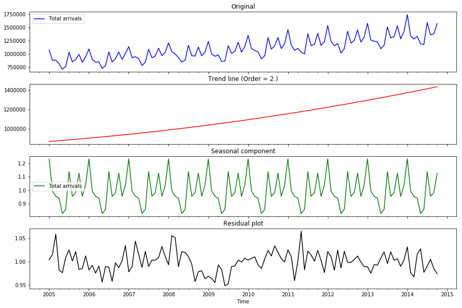

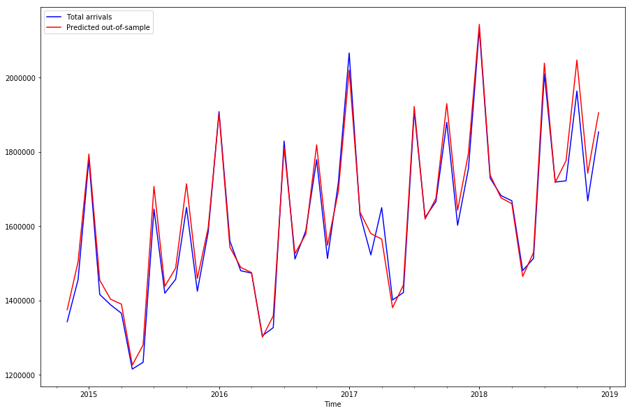

```python
# Visualisation
decomp2.plot_components(data = 'training')
decomp2.plot_test(data = 'test')
```